**MECH437: Artificial Intelligence for M.E.**  
**Midterm Exam - Part 2**  
**Tuesday, 04/11/2023, 09:00~11:00 PM**

By Prof. Seungchul Lee  
http://iai.postech.ac.kr/  
Industrial AI Lab at POSTECH

# Problem 01

Jessica has been working on formulating the temperature (= $y$) of a semiconductor these days. She discovered that a semiconductor's temperature was related to the distance between atoms (= $x$). She assumed that the temperature of a semiconductor had an exponential relationship with the distance between atoms (i.e., $\exp(x)$). She also assumed that the temperature of the semiconductor had a periodic relationship with the distance between atoms (i.e., $\sin(x)$ or $\cos(x)$). Therefore, she tries to formulate the semiconductor temperature with a linear combination of $\sin(x)$, $\cos(x)$ and $\exp(x)$.

(a) Formulate the temperature of semiconductor ($y$) from the given distance between atoms ($x$) using (nonlinear) regression.

$$ y = \theta_0 + \theta_1 \exp(x) + \theta_2 \sin(x) + \theta_3 \cos(x)$$

```python
import numpy as np
import matplotlib.pyplot as plt
import cvxpy as cvx

x = np.linspace(-5,5,30)
y = np.array([15.16043501, 14.93790538, 14.3694888, 13.52210637, 12.49552255,
              11.41059962, 10.39506827, 9.56848955, 9.02817864, 8.8377477,
              9.01961664, 9.55237357, 10.37329569, 11.38573378, 12.47049097,
              13.49985608, 14.35263938, 14.92844055, 15.15946909, 15.01852543,
              14.52220321, 13.72893569, 12.73211624, 11.64910292, 10.60740159,
              9.72965436, 9.1192006, 8.84791056, 8.94772391, 9.40688936])
```

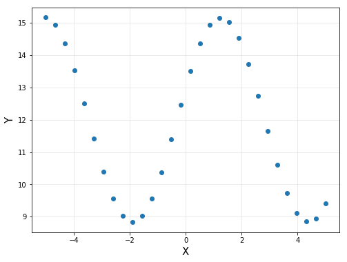

```python
plt.figure(figsize = (8,6))
plt.plot(x, y, 'o', label = "Data")
plt.xlabel("X", fontsize = 15)
plt.ylabel("Y", fontsize = 15)
plt.grid(alpha = 0.3)
plt.show()
```

```python
m = np.shape(x)[0]
x = np.reshape(x,(-1,1))
y = np.reshape(y,(-1,1))

## write your code here to get coefficients of regression (theta)
#
```

(b) Plot your regression function in the range of `xp` below.

```python
xp = np.linspace(-5,5,30).reshape(-1,1)

## write down your code
yp =

plt.figure(figsize = (8,6))
plt.plot(x, y, 'o', label = "Data")
plt.plot(xp, yp, 'r')
plt.xlabel("X", fontsize = 15)
plt.ylabel("y", fontsize = 15)
plt.grid(alpha = 0.3)
plt.show()
```

(c) Jessica finds that if the distance of atom is 8, the temperature of semiconductor is 14.822. Evaluate your model whether it can predict outside the range of training dataset using the following metric.

$$\left\lvert \frac{y_{\text{true}} - y_{\text{pred}}}{y_{\text{true}}} \right\rvert \times 100$$

```python
y_true = 14.822
xp = 8

## write your code here
yp =
```

(d) Peterson was also curious about the relationship between semiconductor temperature and atomic distance. Peterson opted to use polynomial regression to determine the link between two variables. Conduct polynomial regression again with a degree of 7 polynomial basis functions.

$$\hat y = \theta_0 + \theta_1 x + \cdots + \theta_7 x^7$$

```python
import numpy as np
import matplotlib.pyplot as plt
import cvxpy as cvx

x = np.linspace(-5,5,30)
y = np.array([15.16043501, 14.93790538, 14.3694888, 13.52210637, 12.49552255,
              11.41059962, 10.39506827, 9.56848955, 9.02817864, 8.8377477,
              9.01961664, 9.55237357, 10.37329569, 11.38573378, 12.47049097,
              13.49985608, 14.35263938, 14.92844055, 15.15946909, 15.01852543,
              14.52220321, 13.72893569, 12.73211624, 11.64910292, 10.60740159,
              9.72965436, 9.1192006, 8.84791056, 8.94772391, 9.40688936])

m = np.shape(x)[0]
x = np.reshape(x,(-1,1))
y = np.reshape(y,(-1,1))

## write down your code to get coefficients of polynomial regression (theta)
#
```

(e) Plot your polynomial linear regression function using the range of $xp$ below.

```python
xp = np.linspace(-5,5,30).reshape(-1,1)

## write down your code
yp =

plt.figure(figsize = (8,6))
plt.plot(x, y, 'o',label = "Data")
plt.plot(xp, yp, 'r')
plt.xlabel("X", fontsize = 15)
plt.ylabel("y", fontsize = 15)
plt.grid(alpha = 0.3)
plt.show()
```

(f) Peterson also found that if the distance of atom is 8, the temperature of semiconductor is 14.822. Evaluate your model whether it can predict outside the range of training dataset using the following metric.

$$\left\lvert \frac{y_{\text{true}} - y_{\text{pred}}}{y_{\text{true}}} \right\rvert \times 100$$

```python
y_true = 14.822
xp = 8

## write your code here
#
```

(g) Discuss the two models in terms of generalization.

```python
## Write down your own reason using cell or text
#
```

# Problem 02

[Classification with more than two classes]

We learned about a binary classification in class. However, we have to deal with multi-class classifications for some cases. I provide three groups of data in the following python code. Create your own algorithms in python to find linear classification surfaces and classes that each data point belongs to. For this problem, you must use classification algorithms other than SVM. (If you use SVM to solve this question, you will not get a point)

(hint: use binary classification algorithms and extend it to multi-class classification problems)

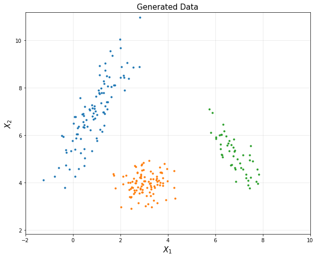

```python
import numpy as np
import matplotlib.pyplot as plt
%matplotlib inline

## generate three simulated clusters

mu1 = np.array([1, 7])
SIGMA1 = 0.8*np.array([[1, 1.5],
                       [1.5, 3]])
X1 = np.random.multivariate_normal(mu1, SIGMA1, 100)

mu2 = np.array([3, 4])
SIGMA2 = 0.3*np.array([[1, 0],
                       [0, 1]])
X2 = np.random.multivariate_normal(mu2, SIGMA2, 100)

mu3 = np.array([7, 5])
SIGMA3 = 0.3*np.array([[1, -1],
                       [-1, 2]])
X3 = np.random.multivariate_normal(mu3, SIGMA3, 50)

plt.figure(figsize = (10, 8))
plt.title('Generated Data', fontsize=15)
plt.plot(X1[:,0], X1[:,1], '.')
plt.plot(X2[:,0], X2[:,1], '.')
plt.plot(X3[:,0], X3[:,1], '.')
plt.xlabel('$X_1$', fontsize = 15)
plt.ylabel('$X_2$', fontsize = 15)
plt.axis('equal')
plt.grid(alpha = 0.3)
plt.axis([-2, 10, 1, 12])
plt.show()
```

```python
## your code here
#
```

# Problem 03

Let's consider a situation where Sam has a dataset (denoted as Z below) that consists of two types of battery data: lithium battery data (denoted as X below) and aluminum battery data (denoted as Y below) where $Z = X + Y$

```python
import numpy as np
import matplotlib.pyplot as plt

np.random.seed(42)

X = np.random.uniform(low=-1, high=1, size=(100, 2))
X[:, 1] = 5 * X[:, 0]**2 + np.random.normal(loc=0, scale=1, size=100) + 5

Y = np.random.uniform(low=-1, high=1, size=(100, 2))
Y[:, 1] = -8 * (Y[:, 0]-0.4)**2 + np.random.normal(loc=0, scale=1, size=100)

Z = np.concatenate([X, Y])

# X: lithium battery data, Y: aluminum battery data, Z: battery dataset
# X.shape = (100,2)
# Y.shape = (100,2)
# Z.shape = (200,2)
```

a) Initially, Sam thought that building a single regression model that can fit into the dataset (Z) would be appropriate, given that the dataset is all about batteries. Using non-linear regression algorithm with polynomial basis functions of degree 5, find and plot an approximate curve of the dataset (Z). Was Sam right about building a single regression model for the dataset? (Is the regression satisfactory?)

$$\hat y = \theta_0 + \theta_1 x + \cdots + \theta_5 x^5$$

```python
# your code here for non-linear regression algorithm
```

```
[[ 2.01678766]
 [ 3.31687851]
 [ 0.82357946]
 [ 1.69506669]
 [-4.34818312]
 [-2.65157812]]
```

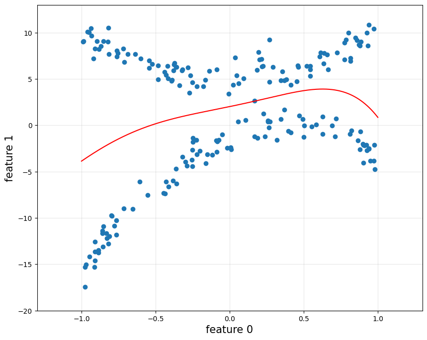

```python
# your code here for the plot
xp = np.linspace(-1, 1, 1000)
yp = # fill in the blank here

plt.figure(figsize = (10, 8))
plt.plot(# fill in the blank here)
plt.plot(xp,yp, 'r')
plt.xlabel('feature 0', fontsize = 15)
plt.ylabel('feature 1', fontsize = 15)
plt.xlim([-1.3, 1.3])
plt.ylim([-20, 13])
plt.grid(alpha = 0.3)
plt.show()
```

b) Sam was not satisfied with the results above, so he decided to classify the dataset (Z) into two separate groups: lithium battery data (X) and aluminum battery data (Y). Although he knew which data points corresponded to each group, he wanted to build a classification model that could classify new data points as either X or Y. To accomplish this, build a classification model using any algorithm you want, and classify X and Y accordingly. Please plot the decision boundary of the classification model.

Note that our decision boundary is defined as follows:

$$ \omega_1 x_1 + \omega_2 x_2 + \omega_0 = 0$$

```python
# your code here for the classification algorithm
```

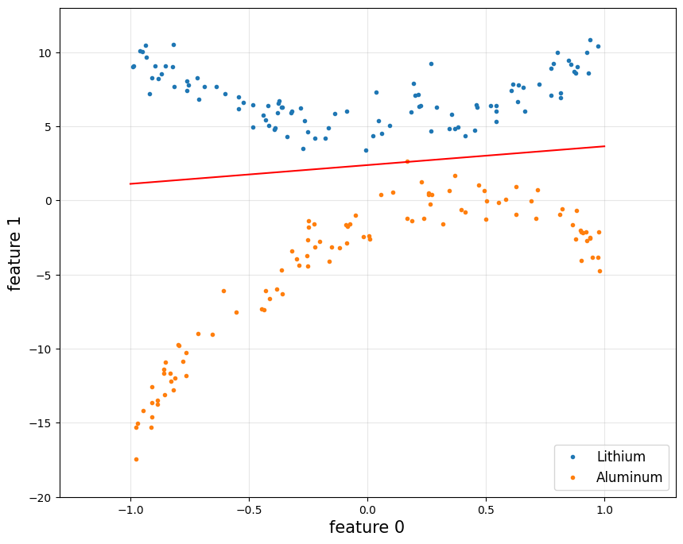

```python
# your code here for the plot
xp = np.linspace(-1, 1)
yp = # fill in the blank here

plt.figure(figsize = (10, 8))
plt.plot(X[:,0], X[:,1], '.', label = 'Lithium')
plt.plot(Y[:,0], Y[:,1], '.', label = 'Aluminum')
plt.plot(xp,yp, 'r')
plt.xlabel('feature 0', fontsize = 15)
plt.ylabel('feature 1', fontsize = 15)
plt.xlim([-1.3, 1.3])
plt.ylim([-20, 13])
plt.grid(alpha = 0.3)
plt.legend(fontsize=12)
plt.show()
```

c) Now, Sam recognizes that it is necessary to build two separate regression algorithms for two separate classes of batteries. Using a non-linear regression algorithm with polynomial basis functions of degree 5, find and plot an approximate curve for each class of data. (Build two regression models for X and Y separately).

```python
# your code here for non-linear regression algorithm on the lithium battery data
```

```
[[ 5.34685326]
 [ 0.18253667]
 [ 3.05649877]
 [-0.28724971]
 [ 1.88837892]
 [ 0.37228213]]
```

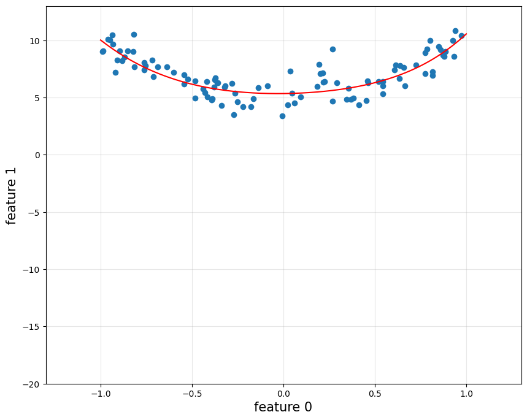

```python
# your code here for the plot
xp = np.linspace(-1, 1, 1000)
yp1 = # fill in the blank here

plt.figure(figsize = (10, 8))
plt.plot(# fill in the blank here)
plt.plot(xp,yp1, 'r')
plt.xlabel('feature 0', fontsize = 15)
plt.ylabel('feature 1', fontsize = 15)
plt.xlim([-1.3, 1.3])
plt.ylim([-20, 13])
plt.grid(alpha = 0.3)
plt.show()
```

```python
# your code here for non-linear regression algorithm on the aluminum battery data
```

```
[[-1.64313707]
 [ 5.8345409 ]
 [-4.53444328]
 [ 0.74265421]
 [-3.75276524]
 [-0.22339565]]
```

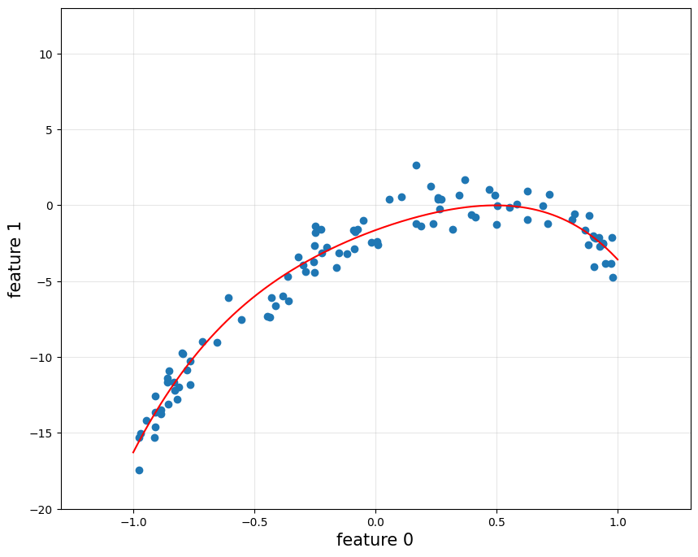

```python
# your code here for the plot
xp = np.linspace(-1, 1, 1000)
yp2 = # fill in the blank here

plt.figure(figsize = (10, 8))
plt.plot(# fill in the blank here)
plt.plot(xp,yp2, 'r')
plt.xlabel('feature 0', fontsize = 15)
plt.ylabel('feature 1', fontsize = 15)
plt.xlim([-1.3, 1.3])
plt.ylim([-20, 13])
plt.grid(alpha = 0.3)
plt.show()
```

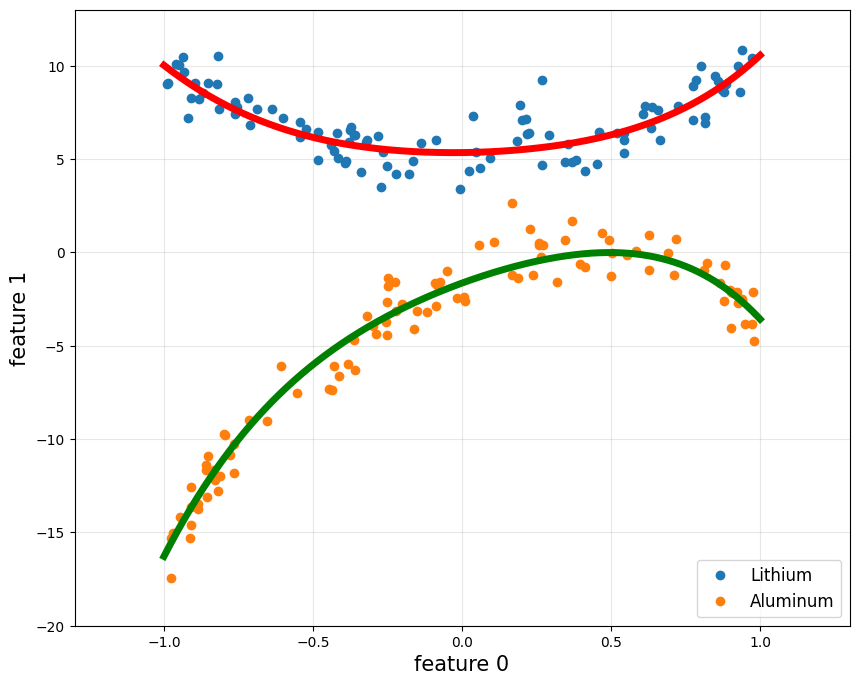

```python
# your code here for the aggregated plot
plt.figure(figsize = (10, 8))
plt.plot(# fill in the blank here)
plt.plot(# fill in the blank here)
plt.plot(xp,yp1, 'r', linewidth =5)
plt.plot(xp,yp2, 'g',linewidth =5)
plt.xlabel('feature 0', fontsize = 15)
plt.ylabel('feature 1', fontsize = 15)
plt.xlim([-1.3, 1.3])
plt.ylim([-20, 13])
plt.grid(alpha = 0.3)
plt.legend(fontsize=12)
plt.show()
```

Take home message: When you receive data for regression analysis, it's essential to have a thorough look at the data. Check whether the data can be separated into different classes. Regression algorithms on the entire data that consists of multiple classes will result in poor performance, while regression algorithms on each class of the data will result in good performance.